# NLP_Final

```python
# Importing the required the libraries
!pip install unidecode
# To read and manipulate the data
import pandas as pd
pd.set_option('max_colwidth', None)

# To visualise the graphs
import matplotlib.pyplot as plt
import seaborn as sns

# Helps to display the images
from PIL import Image

# Helps to extract the data using regular expressions
import re

# Helps to remove the punctuation
import string

# It helps to remove the accented characters

import unidecode

# Importing the NLTK library
import nltk

nltk.download('stopwords')    # Loading the stopwords
nltk.download('punkt')        # Loading the punkt module, used in Tokenization
nltk.download('omw-1.4')      # Dependency for Tokenization
nltk.download('wordnet')      # Loading the wordnet module, used in stemming and lemmatization

# downloading vader lexicon
nltk.download('vader_lexicon')

from nltk.corpus import stopwords

# Helps to visualize the wordcloud
from wordcloud import WordCloud, STOPWORDS, ImageColorGenerator

# Used in Stemming
from nltk.stem.porter import PorterStemmer


# Used in Lemmatization
from nltk.stem import WordNetLemmatizer


from sklearn.feature_extraction.text import CountVectorizer          #For Bag of words
from sklearn.feature_extraction.text import TfidfVectorizer          #For TF-IDF

# Helped to create train and test data
from sklearn.model_selection import train_test_split

# Importing the Random Forest model
from sklearn.ensemble import RandomForestClassifier

# Metrics to evaluate the model
from sklearn.metrics import accuracy_score, classification_report, confusion_matrix

# Unsupervised learning models

# Install vader sentiment package
!pip install vaderSentiment

# Install textblob package
!pip install textblob
```

Part A - Q1 - Import and analyse the data set.

```python
from tensorflow.keras.datasets import imdb
from tensorflow.keras.preprocessing.sequence import pad_sequences
import numpy as np
import pandas as pd

# Load IMDb dataset
(x_train, y_train), (x_test, y_test) = imdb.load_data(num_words=10000)
# Print the shape of features and labels
print("Shape of training data:", x_train.shape)
print("Shape of training labels:", x_train.shape)
print("Shape of test data:", x_test.shape)
print("Shape of test labels:", y_test.shape)

# Print the value of one feature and its label
sample_index = 0
print("\nExample Feature (sequence of integers):")
print(x_train[sample_index])

print("\nCorresponding Label:")
print(y_train[sample_index])
```

```
Shape of training data: (25000,)
Shape of training labels: (25000,)
Shape of test data: (25000,)
Shape of test labels: (25000,)

Example Feature (sequence of integers):
[1, 14, 22, 16, 43, 530, 973, 1622, 1385, 65, 458, 4468, 66, 3941, 4, 173, 36, 256, 5, 25, 100, 43, 838, 112, 50, 670, 2, 9, 35, 480, 284, 5, 150, 4, 172, 112, 167, 2, 336, 385, 39, 4, 172, 4536, 1111, 17, 546, 38, 13, 447, 4, 192, 50, 16, 6, 147, 2025, 19, 14, 22, 4, 1920, 4613, 469, 4, 22, 71, 87,…

Corresponding Label:
1
```

Part A - Q2 - Perform relevant sequence adding on the data.

```python
# Combine training and testing sets
x = np.concatenate((x_train, x_test), axis=0)
y = np.concatenate((y_train, y_test), axis=0)

# Convert word index to word
word_index = imdb.get_word_index()
reverse_word_index = dict([(value, key) for (key, value) in word_index.items()])
decoded_review = ' '.join([reverse_word_index.get(i - 3, '?') for i in x[0]])

# Create a DataFrame with review and sentiment columns
data = {'review': [], 'sentiment': []}

for i in range(len(x)):
    decoded_review = ' '.join([reverse_word_index.get(word - 3, '?') for word in x[i]])
    data['review'].append(decoded_review)
    data['sentiment'].append(y[i])

df = pd.DataFrame(data)

# Display the DataFrame
df.head()
```

|  | review | sentiment |
| --- | --- | --- |
| 0 | ? this film was just brilliant casting location scenery story direction everyone's really suited the part they played and you could just imagine being there robert ? is an amazing actor and now the sa… | 1 |
| 1 | ? big hair big boobs bad music and a giant safety pin these are the words to best describe this terrible movie i love cheesy horror movies and i've seen hundreds but this had got to be on of the worst… | 0 |
| 2 | ? this has to be one of the worst films of the 1990s when my friends i were watching this film being the target audience it was aimed at we just sat watched the first half an hour with our jaws touchi… | 0 |
| 3 | ? the ? ? at storytelling the traditional sort many years after the event i can still see in my ? eye an elderly lady my friend's mother retelling the battle of ? she makes the characters come alive h… | 1 |
| 4 | ? worst mistake of my life br br i picked this movie up at target for 5 because i figured hey it's sandler i can get some cheap laughs i was wrong completely wrong mid way through the film all three o… | 0 |

Part A - Q3 - Perform following data analysis: i) Print shape of features and labels ii) Print value of any one feature and it's label

```python
data = df
df.head(5)
```

|  | review | sentiment |
| --- | --- | --- |
| 0 | ? this film was just brilliant casting location scenery story direction everyone's really suited the part they played and you could just imagine being there robert ? is an amazing actor and now the sa… | 1 |
| 1 | ? big hair big boobs bad music and a giant safety pin these are the words to best describe this terrible movie i love cheesy horror movies and i've seen hundreds but this had got to be on of the worst… | 0 |
| 2 | ? this has to be one of the worst films of the 1990s when my friends i were watching this film being the target audience it was aimed at we just sat watched the first half an hour with our jaws touchi… | 0 |
| 3 | ? the ? ? at storytelling the traditional sort many years after the event i can still see in my ? eye an elderly lady my friend's mother retelling the battle of ? she makes the characters come alive h… | 1 |
| 4 | ? worst mistake of my life br br i picked this movie up at target for 5 because i figured hey it's sandler i can get some cheap laughs i was wrong completely wrong mid way through the film all three o… | 0 |

```python
# Print the shape of features and labels
print("Shape of Features:")
print("Review Data:", data['review'].shape)
print("Sentiment Labels:", data['sentiment'].shape)

# Print the value of one feature and its label
sample_index = 0
print("\nValue of One Feature:")
print("Review:", data['review'][sample_index])
print("Sentiment Label:", data['sentiment'][sample_index])
```

```
Shape of Features:
Review Data: (50000,)
Sentiment Labels: (50000,)

Value of One Feature:
Review: ? this film was just brilliant casting location scenery story direction everyone's really suited the part they played and you could just imagine being there robert ? is an amazing actor and now the same being director ? father came from the same scottish island as myself so i loved the fact …
Sentiment Label: 1
```

```python
data.tail()
```

|  | review | sentiment |
| --- | --- | --- |
| 49995 | ? the book is better than the film mostly because of the writer ? before i saw this film someone who had seen it told me the love depicted in this film isn't real after seeing this film i can see how … | 1 |
| 49996 | ? the largest crowd to ever see a wrestling event in the us took place at ? 6 over ? 000 people showed up to break the rolling stones ? record and this event didn't disappoint at all maybe the biggest… | 1 |
| 49997 | ? i suppose that to say this is an all out terrible movie would be unfair but it's pretty bad the sub disney storyline involves dogs playing soccer and falling in love ? how cute the acting isn't bad … | 0 |
| 49998 | ? in love 2 is the third movie it seemed that its creators took elements from the first two to make this one at the risk of giving out spoilers is kidnapped and the team has to get him back nothing ne… | 0 |
| 49999 | ? a good ol' boy film is almost required to have ? car chases a storyline that has a vague resemblance to plot and at least one very pretty country gal ? with short shorts and a low top the pretty gal… | 0 |

```python
data.info()
```

```
<class 'pandas.core.frame.DataFrame'>
RangeIndex: 50000 entries, 0 to 49999
Data columns (total 2 columns):
 #   Column     Non-Null Count  Dtype
---  ------     --------------  -----
 0   review     50000 non-null  object
 1   sentiment  50000 non-null  int64
dtypes: int64(1), object(1)
memory usage: 781.4+ KB
```

```python
data.duplicated().sum()
```

```
421
```

```python
# dropping the duplicates
data = data.drop_duplicates(keep = 'first')

# checking for duplicate values
data.duplicated().sum()
```

```
0
```

```python
data = data.reset_index(drop = True)
```

```python
# Creating word cloud for negative reviews

negative_reviews = data[data['sentiment'] == 0]

words = ' '.join(negative_reviews['review'])

cleaned_word = " ".join([word for word in words.split()])
```

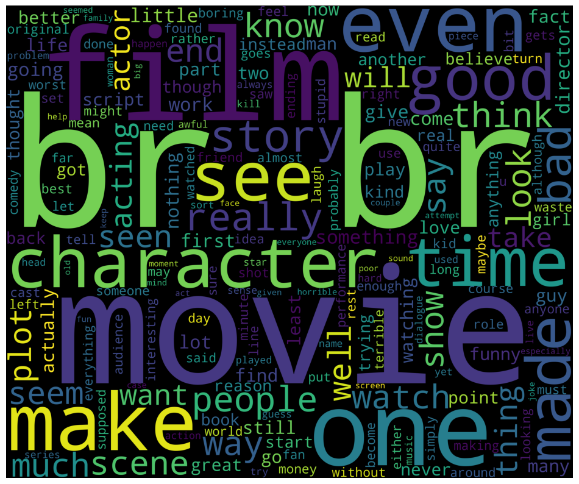

```python
wordcloud = WordCloud(stopwords = STOPWORDS,
                      background_color = 'black',
                      width = 3000,
                      height = 2500
                     ).generate(cleaned_word)
plt.figure(1, figsize = (12, 12))

plt.imshow(wordcloud)

plt.axis('off')

plt.show()
```

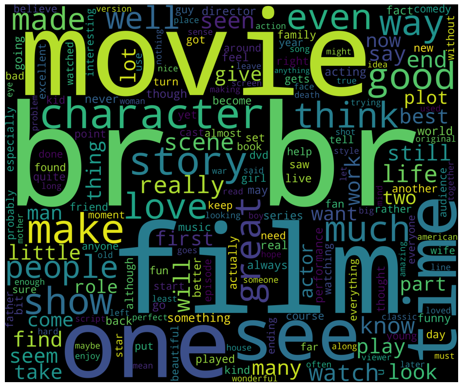

```python
# Creating word cloud for positive reviews
positive_reviews = data[data['sentiment'] == 1]

words = ' '.join(positive_reviews['review'])

cleaned_word = " ".join([word for word in words.split()])
wordcloud = WordCloud(stopwords = STOPWORDS,
                      background_color = 'black',
                      width = 3000,
                      height = 2500
                     ).generate(cleaned_word)
plt.figure(1, figsize = (12, 12))

plt.imshow(wordcloud)

plt.axis('off')

plt.show()
```

```python
# Check the labels
data['sentiment'].unique()
```

```
array([1, 0])
```

```python
# check the count of each labels
data['sentiment'].value_counts()
```

```
1    24881
0    24698
Name: sentiment, dtype: int64
```

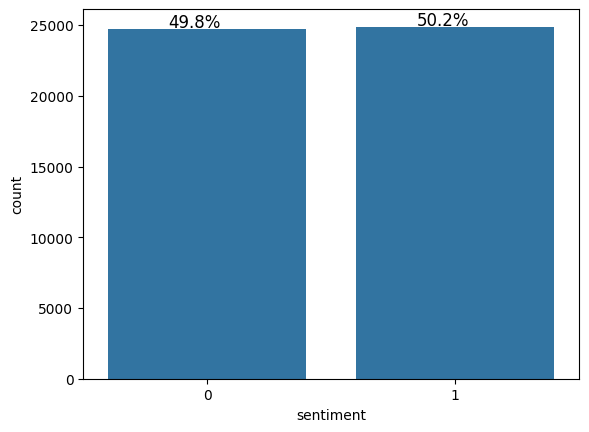

```python
# Plot the distribution of the class label
def bar_plot(data, feature):
    # Creating the countplot
    plot = sns.countplot(x = feature, data = data)

    # Finding the length the whole data
    total = len(data)

    # Creating the percentages to each label in the data
    for p in plot.patches:
        percentage = '{:.1f}%'.format(100 * p.get_height()/total)
        x = p.get_x() + p.get_width() / 2 - 0.05
        y = p.get_y() + p.get_height()
        plot.annotate(percentage, (x, y),ha="center",
            va = "center",
            size = 12,
            xytext = (0, 5),
            textcoords = "offset points")
    plt.show()

bar_plot(data,'sentiment')
```

The dataset is reasonably balanced as the number of samples in each class is close.

Part A - Q4 - Decode the feature value to get original sentence

```python
word_index = imdb.get_word_index()

# Reverse the word index to map integer indices to words
reverse_word_index = dict([(value, key) for (key, value) in word_index.items()])

sample_index = 0

# Decode the feature value to get the original sentence
original_sentence = ' '.join([reverse_word_index.get(i - 3, '?') for i in x_train[sample_index]])

# Print the original sentence
print("Original Sentence:")
print(original_sentence)
```

```
Original Sentence:
? this film was just brilliant casting location scenery story direction everyone's really suited the part they played and you could just imagine being there robert ? is an amazing actor and now the same being director ? father came from the same scottish island as myself so i loved the fact there wa…
```

```python
# Creating the lemmatizer

lm = WordNetLemmatizer()
```

```python
final_corpus = []

for i in range(data.shape[0]):

    # removing the special characetrs, numbers from the data
    review = re.sub('[^a-zA-Z]', ' ', data['review'][i])

    # lowering the text
    review = review.lower()

    review = review.split()

    # removing the accented words
    review = [unidecode.unidecode(word) for word in review]

    # removing the stopwords and creating lemma words to each word present in the each row
    review = [lm.lemmatize(word) for word in review if not word in stopwords.words('english')]

    # joining the corpus
    review = ' '.join(review)

    # Appending the result it into new list named final_corpus

    final_corpus.append(review)
```

```python
final_corpus[0]
```

```
'film brilliant casting location scenery story direction everyone really suited part played could imagine robert amazing actor director father came scottish island loved fact real connection film witty remark throughout film great brilliant much bought film soon released would recommend everyone wat…
```

```python
final_corpus[1]
```

```
'big hair big boob bad music giant safety pin word best describe terrible movie love cheesy horror movie seen hundred got worst ever made plot paper thin ridiculous acting abomination script completely laughable best end showdown cop worked killer damn terribly written clothes sickening funny equal …
```

```python
# saving the cleaned text back to review column
data['review'] = final_corpus
```

```python
data.head(5)
```

|  | review | sentiment |
| --- | --- | --- |
| 0 | film brilliant casting location scenery story direction everyone really suited part played could imagine robert amazing actor director father came scottish island loved fact real connection film witty… | 1 |
| 1 | big hair big boob bad music giant safety pin word best describe terrible movie love cheesy horror movie seen hundred got worst ever made plot paper thin ridiculous acting abomination script completely… | 0 |
| 2 | one worst film friend watching film target audience aimed sat watched first half hour jaw touching floor bad really rest time everyone else theatre started talking leaving generally cry popcorn actual… | 0 |
| 3 | storytelling traditional sort many year event still see eye elderly lady friend mother retelling battle make character come alive passion eye witness one event heath mile life br br course happened ma… | 1 |
| 4 | worst mistake life br br picked movie target figured hey sandler get cheap laugh wrong completely wrong mid way film three friend asleep still suffering worst plot worst script worst movie ever seen w… | 0 |

```python
# Vectorization (Convert text data to numbers).
from sklearn.feature_extraction.text import CountVectorizer

Count_vec = CountVectorizer(max_features = 1000)

data_features = Count_vec.fit_transform(data['review'])

# Convert the data features to array
data_features = data_features.toarray()
```

```python
# Shape of the feature vector
data_features.shape
```

```
(49579, 1000)
```

```python
X = data_features

y = data.sentiment
```

```python
# Function to print the classification report and get confusion matrix in a proper format

def metrics_score(actual, predicted):

    print(classification_report(actual, predicted))

    cm = confusion_matrix(actual, predicted)

    plt.figure(figsize = (8, 5))

    sns.heatmap(cm, annot = True,  fmt = '.2f', xticklabels = ['negative', 'positive'], yticklabels = ['negative', 'positive'])

    plt.ylabel('Actual')

    plt.xlabel('Predicted')

    plt.show()
```

```python
# Split data into training and testing set.

from sklearn.model_selection import train_test_split

X_train, X_test, y_train, y_test = train_test_split(X, y, test_size = 0.25, shuffle = False)
```

```
              precision    recall  f1-score   support

           0       0.83      0.84      0.83      6088
           1       0.84      0.83      0.84      6307

    accuracy                           0.84     12395
   macro avg       0.84      0.84      0.84     12395
weighted avg       0.84      0.84      0.84     12395
```

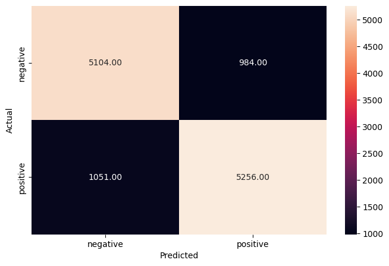

```python
# Training the best model and calculating accuracy on test data

clf = RandomForestClassifier(n_estimators = 100)

clf.fit(X_train, y_train)

y_pred_test = clf.predict(X_test)

metrics_score(y_test, y_pred_test)
```

The model appears to perform well with an accuracy of 84%, and it demonstrates balanced precision and recall for both classes.

```python
X_train[0]
```

[output not shown]

[output cut: 31 more lines]

Part A - Q6 - Use the designed model to print the prediction on any one sample.

```python
import re
from unidecode import unidecode
from nltk.stem import WordNetLemmatizer
from nltk.corpus import stopwords

new_sentence = "The movie exceeded my expectations."

# Removing special characters, numbers, and converting to lowercase
new_sentence = re.sub('[^a-zA-Z]', ' ', new_sentence).lower()

# Removing accented characters
new_sentence = unidecode(new_sentence)

# Tokenizing the sentence
new_sentence = new_sentence.split()

# Removing stopwords and lemmatizing
lemmatizer = WordNetLemmatizer()
new_sentence = [lemmatizer.lemmatize(word) for word in new_sentence if word not in stopwords.words('english')]

# Joining the words back into a sentence
new_sentence = ' '.join(new_sentence)
```

```python
new_sentence
```

```
'movie exceeded expectation'
```

```python
new_sentence_vectorized = Count_vec.transform([new_sentence])

new_sentence_features = new_sentence_vectorized.toarray()

# Ensure that the number of features in the new sentence matches the number of features used during training
if new_sentence_features.shape[1] < X_train.shape[1]:
    new_sentence_features = new_sentence_features[:, :X_train.shape[1]]
```

```python
new_sentence_prediction = clf.predict(new_sentence_features)

print(f"Predicted sentiment for the new sentence: {'Positive' if new_sentence_prediction[0] == 1 else 'Negative'}")
```

```
Predicted sentiment for the new sentence: Positive
```

```python
import pandas as pd
import os
import numpy as np
import matplotlib.pyplot as plt

import tensorflow as tf
from tensorflow.keras.preprocessing.sequence import pad_sequences
from tensorflow.keras.layers import Embedding, LSTM, Dense, Dropout
from tensorflow.keras.preprocessing.text import Tokenizer
from tensorflow.keras.models import Sequential
from tensorflow.keras.optimizers import Adam
```

Part B - Q1 - Read and explore the data

```python
# Load the dataset
dataset_path = '/content/drive/MyDrive/Sarcasm_Headlines_Dataset.json'
df = pd.read_json(dataset_path, lines=True)

# Explore the first few rows of the dataset
print(df.head())
df.info()
```

```
   is_sarcastic  \
0             1
1             0
2             0
3             1
4             1

                                                                          headline  \
0                    thirtysomething scientists unveil doomsday clock of hair loss
1  dem rep. totally nails why congress is falling short on gender, racial equality
2                                eat your veggies: 9 deliciously different recipes
3                             inclement weather prevents liar from getting to work
4                    mother comes pretty close to using word 'streaming' correctly

                                                                                  article_link
0  https://www.theonion.com/thirtysomething-scientists-unveil-doomsday-clock-of-hai-1819586205
1    https://www.huffingtonpost.com/entry/donna-edwards-inequality_us_57455f7fe4b055bb1170b207
2                https://www.huffingtonpost.com/entry/eat-your-veggies-9-delici_b_8899742.html
3   https://local.theonion.com/inclement-weather-prevents-liar-from-getting-to-work-1819576031
4    https://www.theonion.com/mother-comes-pretty-close-to-using-word-streaming-cor-1819575546
<class 'pandas.core.frame.DataFrame'>
RangeIndex: 28619 entries, 0 to 28618
Data columns (total 3 columns):
 #   Column        Non-Null Count  Dtype
---  ------        --------------  -----
 0   is_sarcastic  28619 non-null  int64
 1   headline      28619 non-null  object
 2   article_link  28619 non-null  object
dtypes: int64(1), object(2)
memory usage: 670.9+ KB
```

Part B - Q2 - Retain relevant columns

```python
# Create a new DataFrame with only the relevant columns
data = df[['is_sarcastic', 'headline']]

# Display the first few rows of the new DataFrame
print(data.head())
```

```
   is_sarcastic  \
0             1
1             0
2             0
3             1
4             1

                                                                          headline
0                    thirtysomething scientists unveil doomsday clock of hair loss
1  dem rep. totally nails why congress is falling short on gender, racial equality
2                                eat your veggies: 9 deliciously different recipes
3                             inclement weather prevents liar from getting to work
4                    mother comes pretty close to using word 'streaming' correctly
```

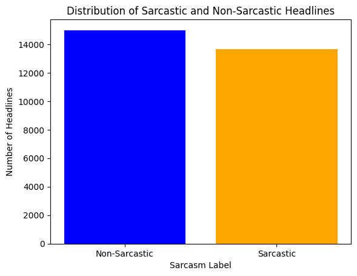

```
0    14985
1    13634
Name: is_sarcastic, dtype: int64
```

```python
sarcastic_counts = data['is_sarcastic'].value_counts()

# Plot the distribution
plt.bar(sarcastic_counts.index, sarcastic_counts.values, color=['blue', 'orange'])
plt.xlabel('Sarcasm Label')
plt.ylabel('Number of Headlines')
plt.title('Distribution of Sarcastic and Non-Sarcastic Headlines')
plt.xticks(sarcastic_counts.index, ['Non-Sarcastic', 'Sarcastic'])
plt.show()

# Display the counts
print(sarcastic_counts)
```

```python
total_headlines = len(data)
percentage_non_sarcastic = (sarcastic_counts[0] / total_headlines) * 100
percentage_sarcastic = (sarcastic_counts[1] / total_headlines) * 100

# Display the percentages
print(f"Percentage of Non-Sarcastic Headlines: {percentage_non_sarcastic:.2f}%")
print(f"Percentage of Sarcastic Headlines: {percentage_sarcastic:.2f}%")
```

```
Percentage of Non-Sarcastic Headlines: 52.36%
Percentage of Sarcastic Headlines: 47.64%
```

The dataset is reasonably balanced as the number of samples in each class is close.

Part B - Q3 - Get length of each sentence

```python
data['sentence_length'] = data['headline'].apply(lambda x: len(x.split()))

# Display the DataFrame with the added 'sentence_length' column
print(data[['headline', 'sentence_length']])
```

```
                                                                                      headline  \
0                                thirtysomething scientists unveil doomsday clock of hair loss
1              dem rep. totally nails why congress is falling short on gender, racial equality
2                                            eat your veggies: 9 deliciously different recipes
3                                         inclement weather prevents liar from getting to work
4                                mother comes pretty close to using word 'streaming' correctly
...                                                                                        ...
28614                                             jews to celebrate rosh hashasha or something
28615  internal affairs investigator disappointed conspiracy doesn't go all the way to the top
28616                  the most beautiful acceptance speech this week came from a queer korean
28617                            mars probe destroyed by orbiting spielberg-gates space palace
28618                                                       dad clarifies this not a food stop

       sentence_length
0                    8
1                   13
2                    7
3                    8
4                    9
...                ...
28614                7
28615               13
28616               12
28617                8
28618                7

[28619 rows x 2 columns]
```

Part B - Q4 - Define parameters

```python
from tensorflow.keras.preprocessing.text import Tokenizer

data['headline'] = data['headline'].str.replace(u'\xa0', u' ')
data['headline'] = data['headline'].str.replace('\u200a', ' ')
data['headline'] = data['headline'].str.replace("'", '')

# Initialize Tokenizer with an out-of-vocabulary token
tokenizer = Tokenizer(oov_token='<oov>')

tokenizer.fit_on_texts(data['headline'])

# Calculate the total number of words
total_words = len(tokenizer.word_index) + 1
print("Total number of words: ", total_words)
```

```
Total number of words:  27246
```

Part B - Q5 - Get indices for words

```python
print("Word: ID")
print("------------")
print("<oov>: ", tokenizer.word_index['<oov>'])
print("and: ", tokenizer.word_index['and'])
print("probe: ", tokenizer.word_index['probe'])
```

```
Word: ID
------------
<oov>:  1
and:  9
probe:  1337
```

Part B - Q6 - Create features and labels

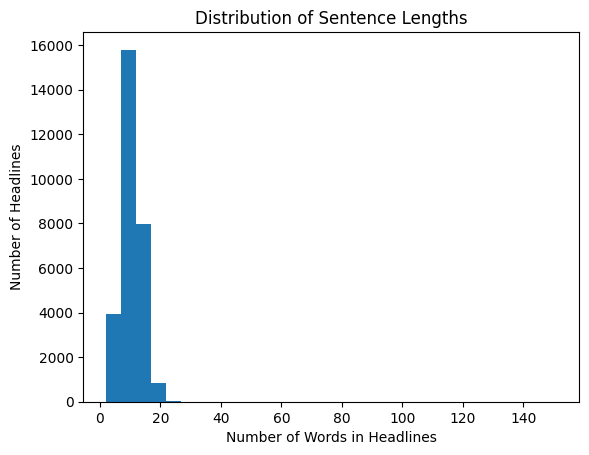

```python
import matplotlib.pyplot as plt

data['headline_length'] = data['headline'].apply(lambda x: len(x.split()))
plt.hist(data['headline_length'], bins=30)
plt.title('Distribution of Sentence Lengths')
plt.xlabel('Number of Words in Headlines')
plt.ylabel('Number of Headlines')
plt.show()
```

```python
from sklearn.model_selection import train_test_split
# Convert headlines to sequences
sequences = tokenizer.texts_to_sequences(data['headline'])

maxlen = 30
padded_sequences = pad_sequences(sequences, maxlen=maxlen, padding='post', truncating='post')

# Create features (X) and labels (y)
X = padded_sequences
y = data['is_sarcastic'].values

# Split the data into training and testing sets
X_train, X_test, y_train, y_test = train_test_split(X, y, test_size=0.2, random_state=42)

# Display the shapes of features and labels
print("X_train shape:", X_train.shape)
print("X_test shape:", X_test.shape)
print("y_train shape:", y_train.shape)
print("y_test shape:", y_test.shape)
```

```
X_train shape: (22895, 30)
X_test shape: (5724, 30)
y_train shape: (22895,)
y_test shape: (5724,)
```

Part B - Q7 - Get vocabulary size

```python
# Get the vocabulary size
vocab_size = len(tokenizer.word_index) + 1

print("Vocabulary Size:", vocab_size)
```

```
Vocabulary Size: 27246
```

Part B - Q8 - Create a weight matrix using GloVe embeddings

```python
import numpy as np
from tensorflow.keras.preprocessing.text import Tokenizer
from tensorflow.keras.preprocessing.sequence import pad_sequences


glove_file = '/content/drive/MyDrive/glove.6B.50d.txt'


# Tokenize the headlines
max_words = 10000
tokenizer = Tokenizer(num_words=max_words, oov_token='<oov>')
tokenizer.fit_on_texts(data['headline'])


# Load GloVe embeddings
embeddings_index = {}
with open(glove_file, 'r', encoding='utf-8') as f:
    for line in f:
        values = line.split()
        word = values[0]
        coefs = np.asarray(values[1:], dtype='float32')
        embeddings_index[word] = coefs

# Create an embedding matrix
embedding_dim = 50  # Adjust based on the GloVe embedding dimension
embedding_matrix = np.zeros((vocab_size, embedding_dim))
for word, i in tokenizer.word_index.items():
    embedding_vector = embeddings_index.get(word)
    if embedding_vector is not None:
        embedding_matrix[i] = embedding_vector

# Pad sequences for input to the model
maxlen = 30
padded_sequences = pad_sequences(tokenizer.texts_to_sequences(data['headline']), maxlen=maxlen, padding='post', truncating='post')

# Display the shapes of the embedding matrix and padded sequences
print("Embedding Matrix Shape:", embedding_matrix.shape)
print("Padded Sequences Shape:", padded_sequences.shape)
```

```
Embedding Matrix Shape: (27246, 50)
Padded Sequences Shape: (28619, 30)
```

Part B - Q9 - Define and compile a LSTM model.

```python
from tensorflow.keras.models import Sequential
from tensorflow.keras.layers import Embedding, Bidirectional, LSTM, Dense, Dropout
from tensorflow.keras.regularizers import l2

model = Sequential()
model.add(Embedding(input_dim=vocab_size, output_dim=embedding_dim, input_length=maxlen, weights=[embedding_matrix], trainable=False))
model.add(Bidirectional(LSTM(128, dropout=0.5, recurrent_dropout=0.5, implementation=2)))
model.add(Dropout(0.5))
model.add(Dense(1, activation='sigmoid', kernel_regularizer=l2(0.01)))

# Compile the model
model.compile(optimizer='adam', loss='binary_crossentropy', metrics=['accuracy'])

# Display the model summary
model.summary()
```

```
Model: "sequential_3"
_________________________________________________________________
 Layer (type)                Output Shape              Param #
=================================================================
 embedding_3 (Embedding)     (None, 30, 50)            1362300

 bidirectional (Bidirectiona  (None, 256)              183296
 l)

 dropout_3 (Dropout)         (None, 256)               0

 dense_3 (Dense)             (None, 1)                 257

=================================================================
Total params: 1,545,853
Trainable params: 183,553
Non-trainable params: 1,362,300
_________________________________________________________________
```

```python
from sklearn.model_selection import train_test_split


# Split the data into training and testing sets
X_train, X_test, y_train, y_test = train_test_split(padded_sequences, y, test_size=0.2, random_state=42)

# Display the shapes of features and labels
print("X_train shape:", X_train.shape)
print("X_test shape:", X_test.shape)
print("y_train shape:", y_train.shape)
print("y_test shape:", y_test.shape)
```

```
X_train shape: (22895, 30)
X_test shape: (5724, 30)
y_train shape: (22895,)
y_test shape: (5724,)
```

Part B - Q10 - Fit the model and check the validation accuracy

```python
# Fit the model
history = model.fit(X_train, y_train, epochs=10, batch_size=32, validation_data=(X_test, y_test))

# Evaluate the model on the validation set
val_loss, val_accuracy = model.evaluate(X_test, y_test)
print(f"Validation Loss: {val_loss:.4f}")
print(f"Validation Accuracy: {val_accuracy:.4f}")
```

```
Validation Loss: 0.3537
Validation Accuracy: 0.8520
```

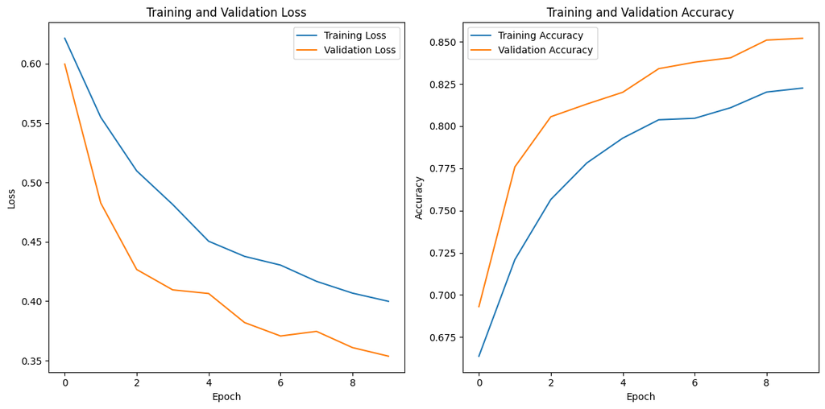

```python
import matplotlib.pyplot as plt


# Plot training and validation loss
plt.figure(figsize=(12, 6))
plt.subplot(1, 2, 1)
plt.plot(history.history['loss'], label='Training Loss')
plt.plot(history.history['val_loss'], label='Validation Loss')
plt.title('Training and Validation Loss')
plt.xlabel('Epoch')
plt.ylabel('Loss')
plt.legend()

# Plot training and validation accuracy
plt.subplot(1, 2, 2)
plt.plot(history.history['accuracy'], label='Training Accuracy')
plt.plot(history.history['val_accuracy'], label='Validation Accuracy')
plt.title('Training and Validation Accuracy')
plt.xlabel('Epoch')
plt.ylabel('Accuracy')
plt.legend()

plt.tight_layout()
plt.show()
```

```python
from tensorflow.keras.preprocessing.sequence import pad_sequences
import numpy as np


# Sample headline to check
headline_to_check = "Wow, what a surprise! The sudden appearance of inclement weather miraculously prevents that notorious truth-teller from making it to work on time"

# Preprocess the headline
sequence_to_check = tokenizer.texts_to_sequences([headline_to_check])
padded_sequence_to_check = pad_sequences(sequence_to_check, maxlen=maxlen, padding='post')

# Make a prediction using the trained model
prediction = model.predict(np.array(padded_sequence_to_check))

# Set the threshold (0.5 in this case)
threshold = 0.5

# Classify as positive or negative based on the threshold
predicted_label = 1 if prediction > threshold else 0

# Output the result
if predicted_label == 1:
    print("Positive (Sarcastic)")
else:
    print("Negative (Non-Sarcastic)")
```

```
Positive (Sarcastic)
```

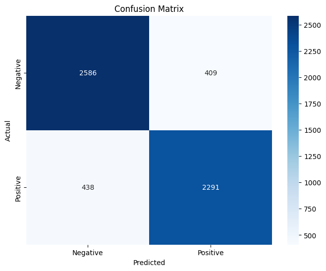

```
Classification Report:
              precision    recall  f1-score   support

           0       0.86      0.86      0.86      2995
           1       0.85      0.84      0.84      2729

    accuracy                           0.85      5724
   macro avg       0.85      0.85      0.85      5724
weighted avg       0.85      0.85      0.85      5724
```

```python
from sklearn.metrics import confusion_matrix, classification_report
import seaborn as sns
import matplotlib.pyplot as plt

y_pred_probs = model.predict(X_test)
y_pred = (y_pred_probs > 0.5).astype(int)

# Convert probabilities to class labels
y_test_labels = (y_test > 0.5).astype(int)

# Compute confusion matrix
cm = confusion_matrix(y_test_labels, y_pred)

# Display the confusion matrix using a heatmap
plt.figure(figsize=(8, 6))
sns.heatmap(cm, annot=True, fmt="d", cmap="Blues", xticklabels=['Negative', 'Positive'], yticklabels=['Negative', 'Positive'])
plt.title('Confusion Matrix')
plt.xlabel('Predicted')
plt.ylabel('Actual')
plt.show()

# Display classification report
print("Classification Report:")
print(classification_report(y_test_labels, y_pred))
```

The model is demonstrating good performance in distinguishing between sarcastic and non-sarcastic headlines, achieving a well-balanced classification across both classes.